# OTIS speed-volume data exploratory analysis

Chi-Hyun Kim

Last updated 2026-02-19

# Spatial coverage

# Temporal coverage

Upshot: Measurement dates vary systematically from year to year. This includes the months covered, the share of weekdays/weekends covered, as well as the share of weekends by month.

The temporal distribution of speed data is quite similar to volume data but not exactly the same.

Coverage of data through the hours of the day is even (i.e., for each measurement instance there is one row for each hour).

## Speed

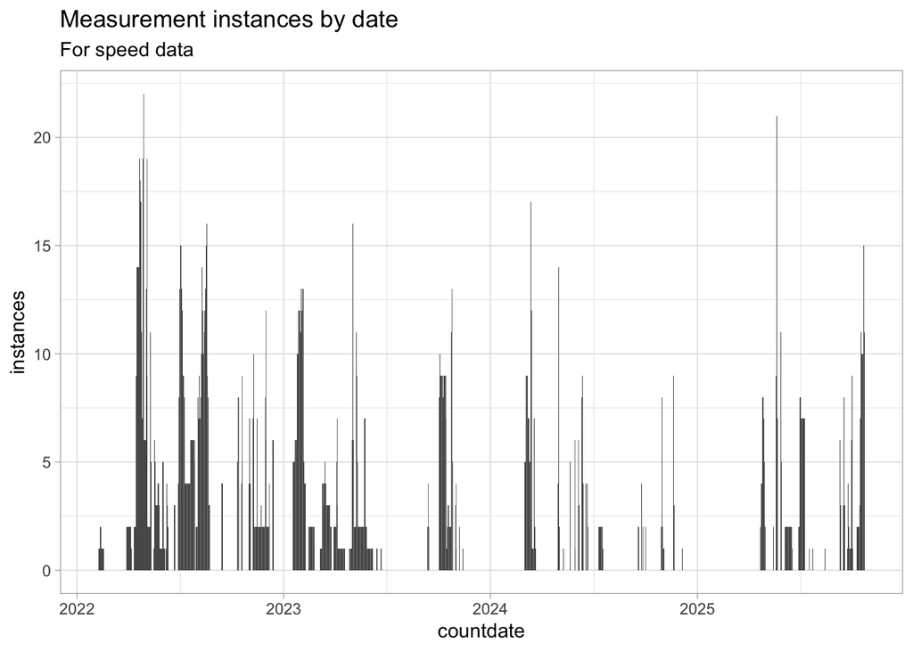

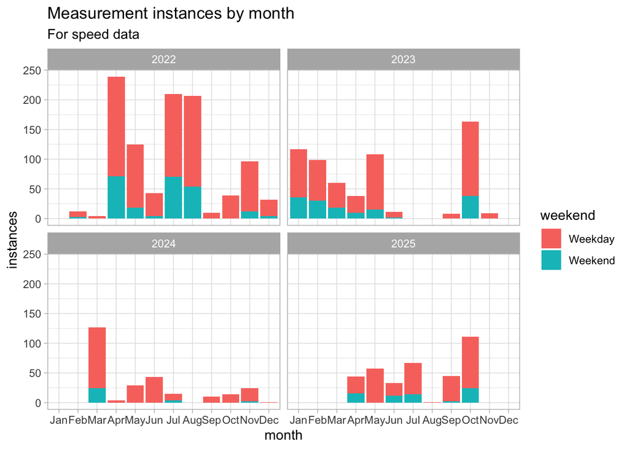

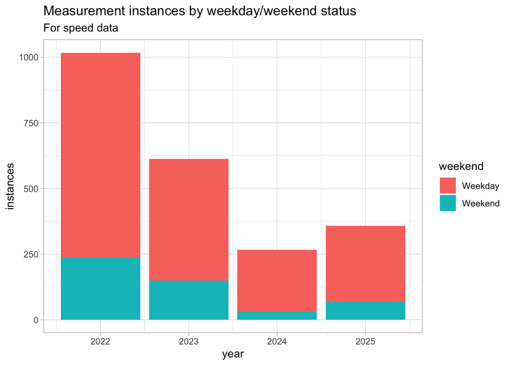

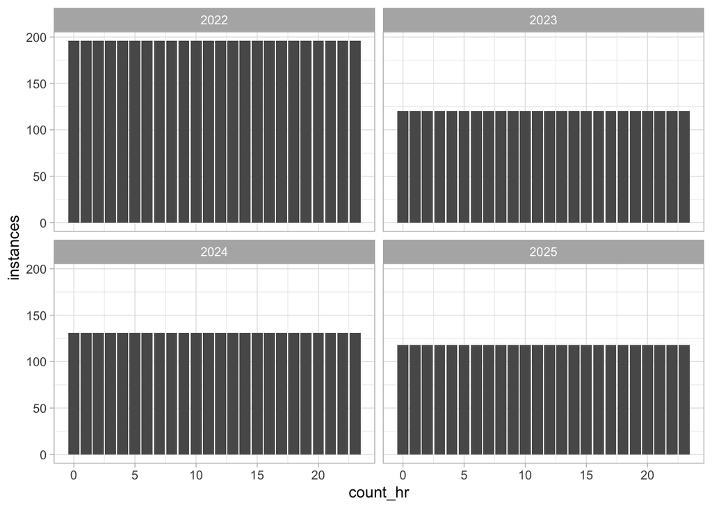

## Volume

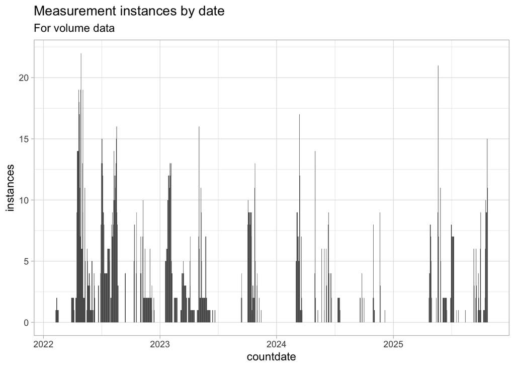

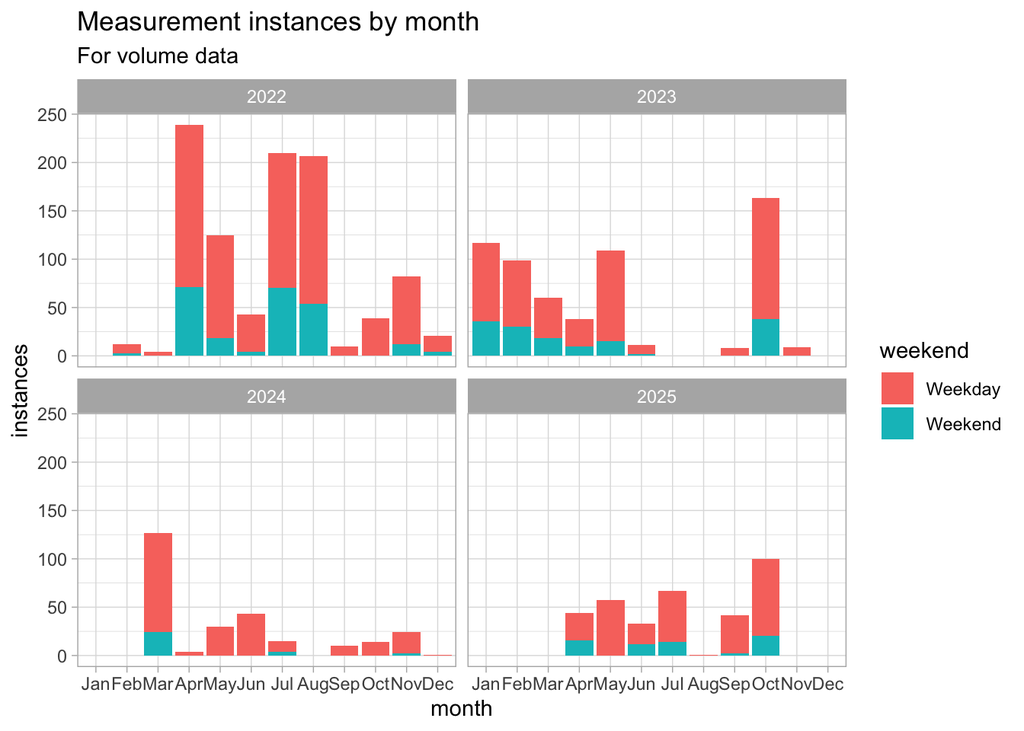

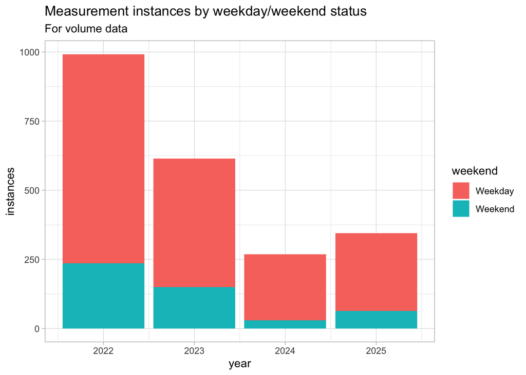

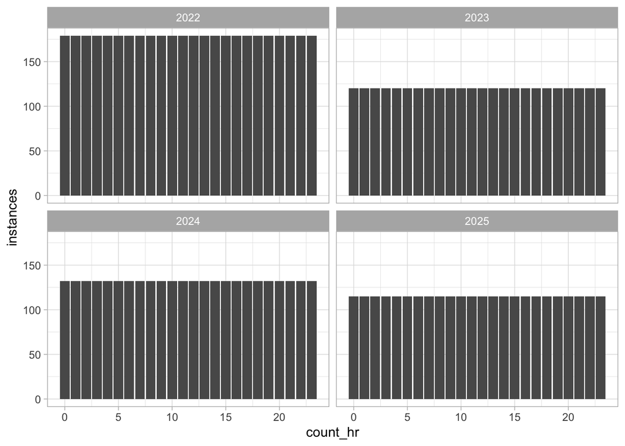

# Speeding descriptives

## Characteristics of measurement locations

Joining the 2022-2025 speed measurement data spatially to Philadelphia street centerlines, we get this coverage:

[interactive chart not shown]

The distribution of speed measurement points by roadway type is thus:

| Roadway type | N | Percent |
| --- | --- | --- |
| Major Arterial | 230.00 | 39.86% |
| Minor Arterial | 166.00 | 28.77% |
| Collector | 132.00 | 22.88% |
| Local | 20.00 | 3.47% |
| High Speed Ramps | 20.00 | 3.47% |
| Low Speed Ramps | 8.00 | 1.39% |
| Expressways | 1.00 | 0.17% |

## Speeding by time of day

### Overall

#### Binary

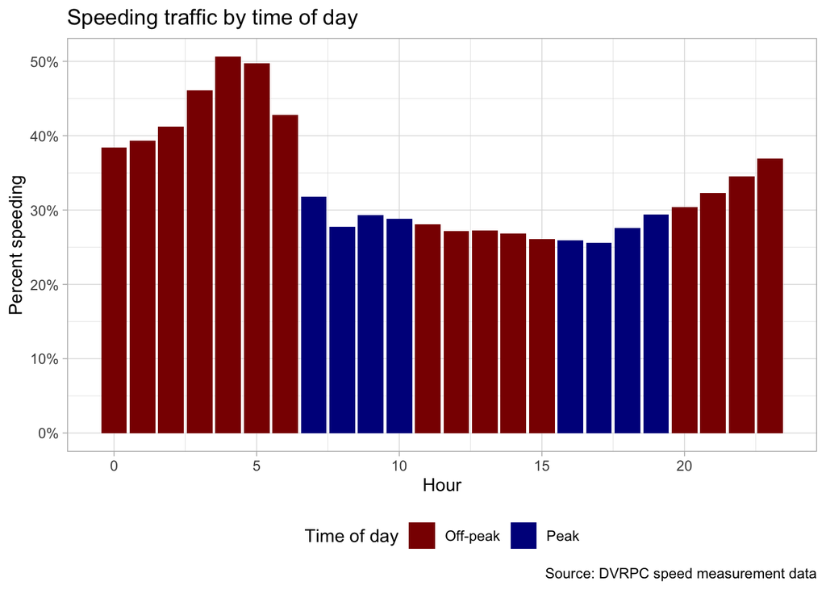

#### Detailed

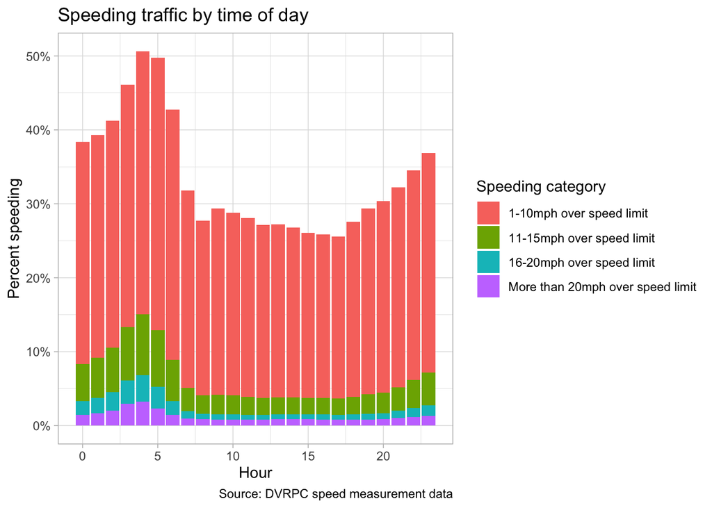

### By roadway type

#### Binary

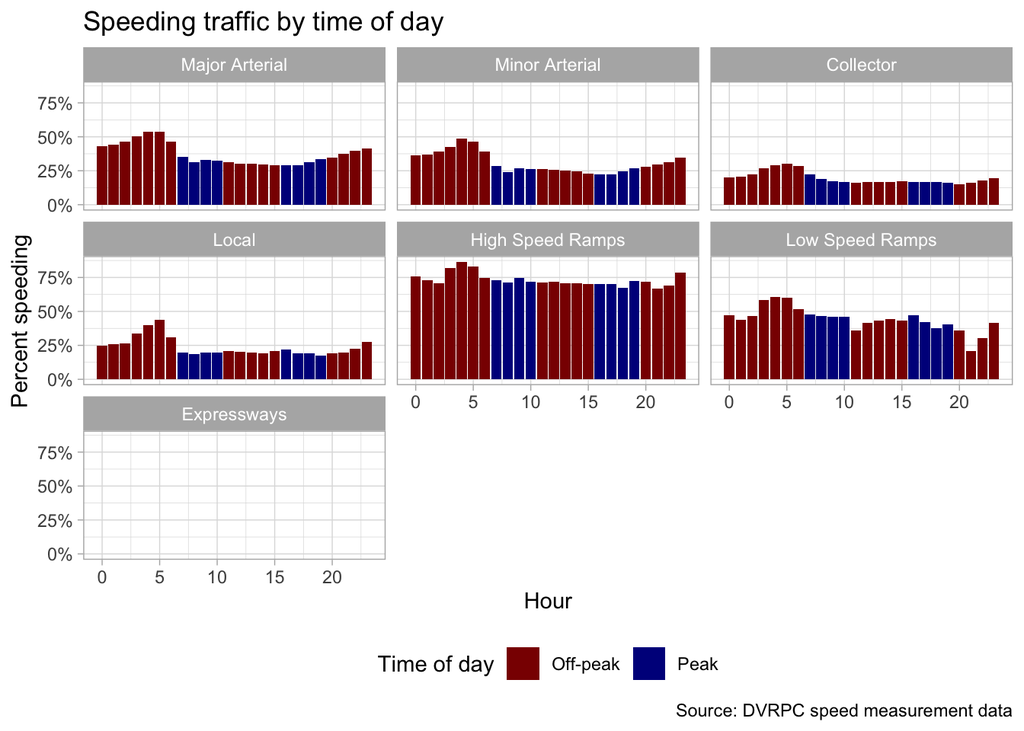

#### Detailed

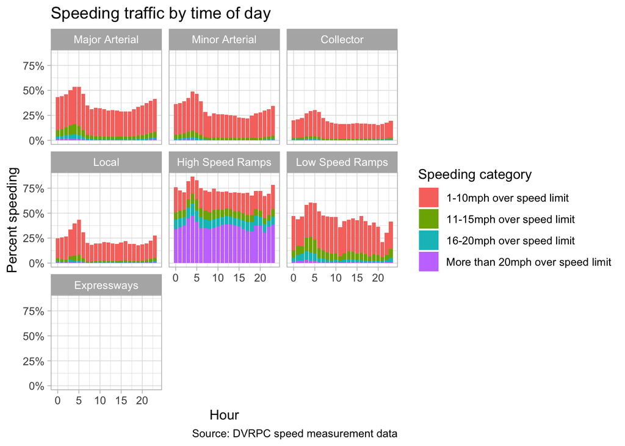

### Off-peak speed corridors

Where are the roadways where the prevalence of speeding at off-peak hours is the highest?

#### Any speeding

The table below shows roadway type distribution for segments where more than half of traffic speeds in off-peak hours.

| Roadway type | N | Percent |
| --- | --- | --- |
| Major Arterial | 76.00 | 48.10% |
| Minor Arterial | 37.00 | 23.42% |
| Collector | 24.00 | 15.19% |
| Local | 2.00 | 1.27% |
| High Speed Ramps | 16.00 | 10.13% |
| Low Speed Ramps | 3.00 | 1.90% |
| Expressways | 0.00 | 0.00% |

Major arterials and high speed ramps are disproportionately prone to speeding drivers in off-peak hours.

The map below shows the location of these majority-speeding roadways.

[interactive chart not shown]

#### High speeding

The table below shows roadway type distribution for segments where more than 10% of traffic speeds 11mph or more over the limit in off-peak hours.

| Roadway type | N | Percent |
| --- | --- | --- |
| Major Arterial | 53.00 | 55.79% |
| Minor Arterial | 19.00 | 20.00% |
| Collector | 6.00 | 6.32% |
| Local | 2.00 | 2.11% |
| High Speed Ramps | 13.00 | 13.68% |
| Low Speed Ramps | 2.00 | 2.11% |
| Expressways | 0.00 | 0.00% |

Major arterials and high speed ramps are even more disproportionately prone to high-speeding drivers in off-peak hours.

The map below shows the location of these high-speeding roadways.

[interactive chart not shown]

## Relationship between volume and speeding

Are drivers more likely to speed for a given roadway type if overall volume is lower?

### Any speeding

There doesn’t seem to be any definitive pattern.

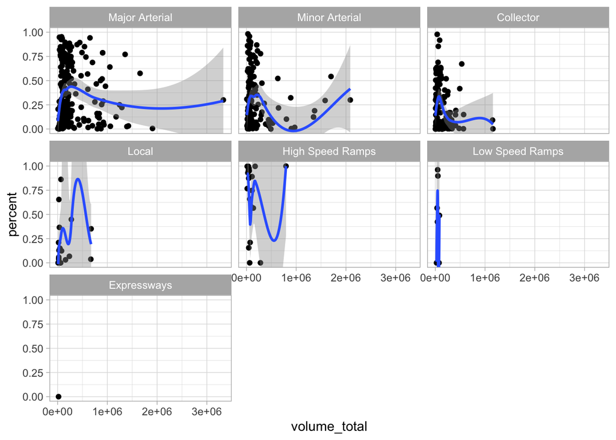

### High speeding

There doesn’t seem to be any definitive pattern.

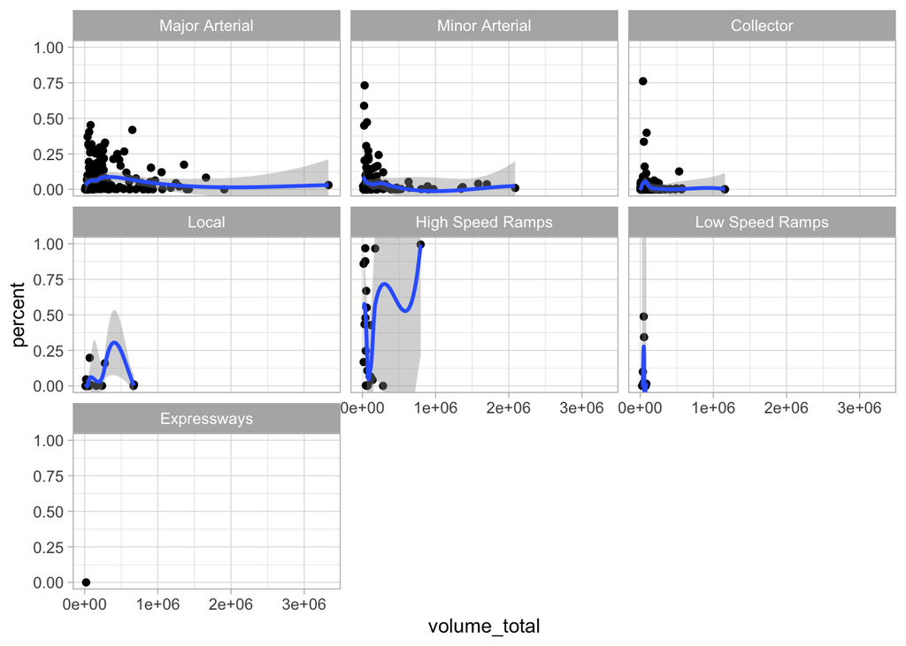